# assignment 2

```r
library(dbplyr)
library(readr)
library(stringr)
library(tidyverse)
survey <- read_csv("data/survey.csv")
survey = survey[-64,]
survey <- survey %>%
  mutate(Q1 = sub("A", "1", Q1))%>%
  mutate(Q1 = sub("B", "2", Q1))%>%
  mutate(Q1 = sub("C", "3", Q1))%>%
  mutate(Q1 = sub("D", "4", Q1))%>%
  mutate(Q1 = sub("E", "Other", Q1))

survey <- survey %>%
  mutate(Q2 = sub("1/2", "0.5", Q2)) %>%
  mutate(Q2 = sub(" hours", "", Q2)) %>%
  mutate(Q2 = sub("\n", "", Q2)) %>%
  mutate(Q2 = sub("hrs", "", Q2)) %>%
  mutate(Q2 = sub("HOUR", "", Q2)) %>%
  mutate(Q2 = sub("4/7", "0.57", Q2)) %>%
  mutate(Q2 = sub("three times", "", Q2))
survey$Q2[27] <- "2.0"
survey <- survey %>% mutate(Q2 = as.numeric(Q2))


survey <- survey %>%
  mutate(Q4 = sub("alt rock", "Alternative Rock", Q4))%>%
  mutate(Q4 = sub("-", "", Q4))%>%
  mutate(Q4 = sub("classical", "Classical", Q4))%>%
  mutate(Q4 = sub("hip-hop", "Hip Hop", Q4))%>%
  mutate(Q4 = sub("hip-pop", "Hip Hop", Q4))%>%
  mutate(Q4 = sub("hip hop", "Hip Hop", Q4))%>%
  mutate(Q4 = sub("Hip hop", "Hip Hop", Q4))%>%
  mutate(Q4 = sub("Hiphop", "Hip Hop", Q4))%>%
  mutate(Q4 = sub("hipPop", "Hip Hop", Q4))%>%
  mutate(Q4 = sub("hiphop", "Hip Hop", Q4))%>%
  mutate(Q4 = sub("hipPop", "Hip Hop", Q4))%>%
  mutate(Q4 = sub("jazz", "Jazz", Q4))%>%
  mutate(Q4 = sub("pop", "Pop", Q4))%>%
  mutate(Q4 = sub("pop music", "Pop music", Q4))%>%
  mutate(Q4 = sub("RnB", "R&B", Q4))%>%
  mutate(Q4 = sub("RNB", "R&B", Q4))%>%
  mutate(Q4 = sub("rnb", "R&B", Q4))

survey <- survey %>%
  mutate(Q5 = sub("24HOUR", "24", Q5)) %>%
  mutate(Q5 = sub("35 hours", "35", Q5)) %>%
  mutate(Q5 = sub("6 hours", "6", Q5)) %>%
  mutate(Q5 = sub("40hrs", "40", Q5)) %>%
  mutate(Q5 = sub("40 hours", "40", Q5)) %>%
  mutate(Q5 = sub("Choosing not to answer", "NA", Q5)) %>%
  mutate(Q5 = sub("24 Hours", "24", Q5))

survey <- survey %>%
  mutate(Q6 = sub("fly","Fly", Q6)) %>%
  mutate(Q6 = sub("flying","Fly", Q6)) %>%
  mutate(Q6 = sub("Flying","Fly", Q6)) %>%
  mutate(Q6 = sub("forecasting the future","forecasting", Q6)) %>%
  mutate(Q6 = sub("imortality","immortality", Q6)) %>%
  mutate(Q6 = sub("insivibility","Invisibility", Q6)) %>%
  mutate(Q6 = sub("invisible","Invisibility", Q6)) %>%
  mutate(Q6 = sub("Invisible","Invisibility", Q6)) %>%
  mutate(Q6 = sub("teleportation","Teleportation", Q6)) %>%
  mutate(Q6 = sub("teleporting","Teleportation", Q6)) %>%
  mutate(Q6 = sub("time travel","Time travel", Q6))

survey <- survey %>%
  mutate(Q7 = sub("A","Two sizes too big", Q7)) %>%
  mutate(Q7 = sub("B","One size too small", Q7)) %>%
  mutate(Q7 = sub("C","Neither of these", Q7))

survey <- survey %>%
  mutate(Q8 = sub("A", "[0,3)", Q8)) %>%
  mutate(Q8 = sub("B", "[3,6)", Q8)) %>%
  mutate(Q8 = sub("C", "[6,9)", Q8)) %>%
  mutate(Q8 = sub("D", "[9,12)", Q8)) %>%
  mutate(Q8 = sub("E", "More than 12", Q8))


survey <- survey %>%
  mutate(Q9 = sub("dont watch", "None", Q9)) %>%
  mutate(Q9 = sub("dont watch tv", "None", Q9)) %>%
  mutate(Q9 = sub("I do not watch television.", "None", Q9)) %>%
  mutate(Q9 = sub("I don't", "None", Q9)) %>%
  mutate(Q9 = sub("I don't watch television", "None", Q9)) %>%
  mutate(Q9 = sub("I don't watch television.", "None", Q9)) %>%
  mutate(Q9 = sub("i don't watch tv", "None", Q9)) %>%
  mutate(Q9 = sub("No television", "None", Q9)) %>%
  mutate(Q9 = sub("non", "None", Q9)) %>%
  mutate(Q9 = sub("none", "None", Q9)) %>%
  mutate(Q9 = sub("Nothing", "None", Q9)) %>%
  mutate(Q9 = sub("stan", "Stan", Q9)) %>%
  mutate(Q9 = sub("None watch television", "None", Q9)) %>%
  mutate(Q9 = sub("None.", "None", Q9)) %>%
  mutate(Q9 = sub("Nonee", "None", Q9)) %>%
  mutate(Q9 = sub("None tv", "None", Q9)) %>%
  mutate(Q9 = sub("Nonetv", "None", Q9)) %>%
  mutate(Q9 = sub("netflix", "Netflix", Q9))

survey <- survey %>% mutate(Q10 = as.numeric(Q10))
survey <- survey %>%
  mutate(Q11 = sub("A", "Elective", Q11)) %>%
  mutate(Q11 = sub("B", "Core", Q11))

survey <- survey %>%
  mutate(Q12 = sub("A", "Single", Q12)) %>%
  mutate(Q12 = sub("B", "Double", Q12))

survey <- survey %>%
  mutate(Q13 = sub("$15", "15", Q13)) %>%
  mutate(Q13 = sub("$30", "30", Q13)) %>%
  mutate(Q13 = sub("$35", "35", Q13)) %>%
  mutate(Q13 = sub("$5", "5", Q13)) %>%
  mutate(Q13 = sub("35 dollars", "35", Q13))
survey <- survey %>% mutate(Q13 = as.numeric(Q13))
survey <- survey %>%
  mutate(Q14 = sub("A", "0", Q14)) %>%
  mutate(Q14 = sub("B", "1", Q14)) %>%
  mutate(Q14 = sub("C", "2", Q14)) %>%
  mutate(Q14 = sub("D", "3", Q14)) %>%
  mutate(Q14 = sub("E", "4", Q14)) %>%
  mutate(Q14 = sub("F", "5", Q14)) %>%
  mutate(Q14 = sub("G", "More than 5", Q14))

survey <- survey %>%
  mutate(Q15 = sub("A", "Cucumbers", Q15)) %>%
  mutate(Q15 = sub("B", "Carrots", Q15)) %>%
  mutate(Q15 = sub("C", "Neither", Q15)) %>%
  mutate(Q15 = sub("Neitherarrots", "Carrots", Q15)) %>%
  mutate(Q15 = sub("Neitherucumbers", "Cucumbers", Q15))

survey <- survey %>%
  mutate(Q16 = sub("A", "dog", Q16)) %>%
  mutate(Q16 = sub("B", "cat", Q16)) %>%
  mutate(Q16 = sub("C", "rabbit", Q16)) %>%
  mutate(Q16 = sub("D", "bird", Q16)) %>%
  mutate(Q16 = sub("E", "reptile", Q16)) %>%
  mutate(Q16 = sub("F", "other", Q16))

survey <- survey %>%
  mutate(Q17=sub("A","1",Q17)) %>%
  mutate(Q17=sub("B","2",Q17))

survey <- survey %>%
  mutate(Q18=sub("listen to music","Music", Q18)) %>%
  mutate(Q18=sub("sport","Sports", Q18)) %>%
  mutate(Q18=sub("watch youtube","Video", Q18)) %>%
  mutate(Q18=sub("watch tv","TV", Q18)) %>%
  mutate(Q18=sub("watch vedio","Video", Q18)) %>%
  mutate(Q18=sub("gym internet surfing","Sports", Q18)) %>%
  mutate(Q18=sub("Basketball","Sports", Q18)) %>%
  mutate(Q18=sub("sleep","Sleep", Q18)) %>%
  mutate(Q18=sub("cook","Cook", Q18)) %>%
  mutate(Q18=sub("youtube","Video", Q18)) %>%
  mutate(Q18=sub("Card games","Games", Q18)) %>%
  mutate(Q18=sub("gaming","Gambling", Q18)) %>%
  mutate(Q18=sub("training my aim in different FPS games","Games", Q18)) %>%
  mutate(Q18=sub("Gym","Sport", Q18)) %>%
  mutate(Q18=sub("Climbing","Sports", Q18)) %>%
  mutate(Q18=sub("Play games","Games", Q18)) %>%
  mutate(Q18=sub("social media","Social media", Q18)) %>%
  mutate(Q18=sub("video game","Games", Q18)) %>%
  mutate(Q18=sub("computer games","Games", Q18)) %>%
  mutate(Q18=sub("play games","Games", Q18)) %>%
  mutate(Q18=sub("instagram","Social media", Q18)) %>%
  mutate(Q18=sub("Game","Games", Q18)) %>%
  mutate(Q18=sub("league of legends","Games", Q18)) %>%
  mutate(Q18=sub("Read, Play Guitar, Electronics, Sport","Read", Q18)) %>%
  mutate(Q18=sub("the office","Work", Q18)) %>%
  mutate(Q18=sub("This is us and cry","NA", Q18)) %>%
  mutate(Q18=sub("Swim, cook","Sports", Q18)) %>%
  mutate(Q18=sub("Sport","Sports", Q18)) %>%
  mutate(Q18=sub("tv","TV", Q18)) %>%
  mutate(Q18=sub("Have a trip","Traveling", Q18)) %>%
  mutate(Q18=sub("piano","Instruments", Q18)) %>%
  mutate(Q18=sub("Play video games","Games", Q18)) %>%
  mutate(Q18=sub("Study more","Study", Q18)) %>%
  mutate(Q18=sub("listen music","Music", Q18)) %>%
  mutate(Q18=sub("Watch Something/ Light Exercise","Video", Q18)) %>%
  mutate(Q18=sub("gaming","Gambling", Q18)) %>%
  mutate(Q18=sub("youtube","Video", Q18)) %>%
  mutate(Q18=sub("play my phone","Social media", Q18)) %>%
  mutate(Q18=sub("work","Work", Q18)) %>%
  mutate(Q18=sub("Hang out with friends","Social media", Q18)) %>%
  mutate(Q18=sub("Your mum","NA", Q18)) %>%
  mutate(Q18=sub("Gamess","Games", Q18)) %>%
  mutate(Q18=sub("Sportss","Sports", Q18)) %>%
  mutate(Q18=sub("Games.", "Games", Q18)) %>%
  mutate(Q18=sub("internet, stretch, water","Social media", Q18))
survey$Q18[34] <- "Social media"

survey <- survey %>%
  mutate(Q19=sub("A","Windows",Q19)) %>%
  mutate(Q19=sub("B","Mac",Q19)) %>%
  mutate(Q19=sub("C","Linux",Q19)) %>%
  mutate(Q19=sub("D", "Other", Q19))

survey <- survey %>%
  mutate(Q21=sub("7;30","7.5",Q21))
survey <- survey %>% mutate(Q21 = as.numeric(Q21))

survey <- survey %>%
  mutate(Q22=sub("3days","3",Q22))

survey <- survey %>%
  mutate(Q23=sub("1997","21",Q23)) %>%
  mutate(Q23=sub("XXI","21",Q23))

survey <- survey %>%
  mutate(Q24=sub("I don't know","NA",Q24))

#Q25
survey <- survey %>%
  mutate(Q25 = sub("Table Tennis", "table tennis", Q25))%>%
  mutate(Q25 = sub("Hockey", "hockey", Q25))%>%
  mutate(Q25 = sub("Basketball", "basketball", Q25))%>%
  mutate(Q25 = sub("Tennis", "tennis", Q25))%>%
  mutate(Q25 = sub("Fencing", "fencing", Q25))%>%
  mutate(Q25 = sub("Electronic games and running", "electronic games and running", Q25))%>%
  mutate(Q25 = sub("Climbing", "climbing", Q25))%>%
  mutate(Q25 = sub("Soccer", "soccer", Q25))%>%
  mutate(Q25 = sub("Gym", "gym", Q25))%>%
  mutate(Q25 = sub("Yes", "NA", Q25))%>%
  mutate(Q25 = sub("Badminton", "badminton", Q25))%>%
  mutate(Q25 = sub("European Handball", "european handball", Q25))%>%
  mutate(Q25 = sub("Choosing not to answer", "NA", Q25))%>%
  mutate(Q25 = sub("swim", "swimming", Q25))%>%
  mutate(Q25 = sub("Cricket", "cricket", Q25))%>%
  mutate(Q25 = sub("Curling", "curling", Q25))%>%
  mutate(Q25 = sub("Snowboarding", "snowboarding", Q25)) %>%
  mutate(Q25 = sub("swimmingming", "swimming",Q25))


#Q26
survey <- survey %>%
  mutate(Q26 = sub("A", "female", Q26)) %>%
  mutate(Q26 = sub("B", "male", Q26)) %>%
  mutate(Q26 = sub("C", "other", Q26))


#Q27
survey <- survey %>%
  mutate(Q27 = sub("A", "fridge", Q27)) %>%
  mutate(Q27 = sub("B", "pantry", Q27))


#Q28
survey <- survey %>%
  mutate(Q28 = sub("A", "0", Q28)) %>%
  mutate(Q28 = sub("B", "1-5", Q28)) %>%
  mutate(Q28 = sub("C", "6-10", Q28)) %>%
  mutate(Q28 = sub("D", "11-20", Q28)) %>%
  mutate(Q28 = sub("E", "More than 20", Q28))

#Q29
survey <- survey %>%
  mutate(Q29 = sub("A", "Yes", Q29)) %>%
  mutate(Q29 = sub("B", "No", Q29))

#Q30
survey <- survey %>%
  mutate(Q30 = sub("A", "No", Q30)) %>%
  mutate(Q30 = sub("B", "Yes", Q30))


#Q31
survey <- survey %>%
  mutate(Q31 = sub("A", "Yes", Q31)) %>%
  mutate(Q31 = sub("B", "No", Q31))


#Q32
survey <- survey %>%
  mutate(Q32 = sub("Spatula", "spatula", Q32))%>%
  mutate(Q32 = sub("Soup spoon", "soup spoon", Q32))%>%
  mutate(Q32 = sub("Fork", "fork", Q32))%>%
  mutate(Q32 = sub("Ladle", "ladle", Q32))%>%
  mutate(Q32 = sub("Whisk", "whisk", Q32))%>%
  mutate(Q32 = sub("None", "none", Q32))%>%
  mutate(Q32 = sub("Grater", "grater", Q32))%>%
  mutate(Q32 = sub("Spoon", "spoon", Q32))%>%
  mutate(Q32 = sub("Chopsticks", "chopsticks", Q32))%>%
  mutate(Q32 = sub("That thing that cuts eggs", "that thing that cuts eggs", Q32))%>%
  mutate(Q32 = sub("Knife", "knife", Q32))%>%
  mutate(Q32 = sub("IKEA soup ladle", "ikea soup ladle", Q32))%>%
  mutate(Q32 = sub("a spoon", "spoon", Q32))%>%
  mutate(Q32 = sub("Fridge", "fridge", Q32))%>%
  mutate(Q32 = sub("chopstick(s)", "chopsticks", Q32))%>%
  mutate(Q32 = sub("Spork", "spork", Q32))%>%
  mutate(Q32 = sub("Icecream scooper", "icecream scooper", Q32))%>%
  mutate(Q32 = sub("Coffee Machine", "coffee machine", Q32))%>%
  mutate(Q32 = sub("Oven mitt", "oven mitt", Q32))






#NOTES Q32
#Changed "a spoon" -> "spoon"
#Changed "chopstick(s)" -> "chopsticks"
#mutated to lower case

#NOTES Q25
#Changed "yes" -> "NA"
#Changed "Choosing not to answer" -> "NA"
#Changed "swim -> "swimming"
#mutated to lower case
```

Codes above are demonstrations of data cleaning. There were simple questions to clean such as to replace “A” or “B” with actual answers, while some open-ended questions were difficult to clean as answers varied in many different ways, such as spelling, capitals, spacing etc.For example, “Television” had may variations such as “TV”, “Tele”, “television” and so on. We had to make sure to group them into one single name so it’ll be analysed and interpreted properly. Some answers such as “True” or “False” required no cleaning as those answers were clear from the beginning. Overall this set of data was very laborious to clean, ways to overcome this may be making all questions into multiple choice, or only accepting certain characters or phrases (such as only capitals, or no symbols/non-letter characters).

```r
library(dbplyr)
library(readr)
library(stringr)
library(tidyverse)
survey <- read_csv("data/survey.csv")
```

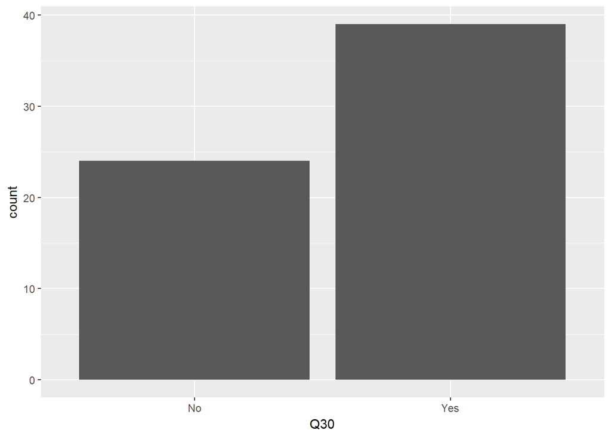

```r
survey = survey[-64,]
survey <- survey %>%
  mutate(Q30 = sub("A", "No", Q30)) %>%
  mutate(Q30 = sub("B", "Yes", Q30))

ggplot(survey, aes(x=Q30)) + geom_bar()
```

Two bar charts are shown here. Q30 is “Are you struggling with this unit” and Q31 is “Do you like ETC1010”. In the bar chart for Q30, the answer “Yes” dominates “No”. Nearly two-thirds of the cohort show that they’re struggling with this unit. Reasons for that might be the ways of teaching, how the class is set out and the information/study materials given afterclass. To increase the number of “No”, tutors and our lovely CE can improve this unit by ways such as supplying us with actual lecture notes, explaining codes more thoroughly and creating a file with useful codes for us to use not only for this unit, but for our future data science units at Monash.

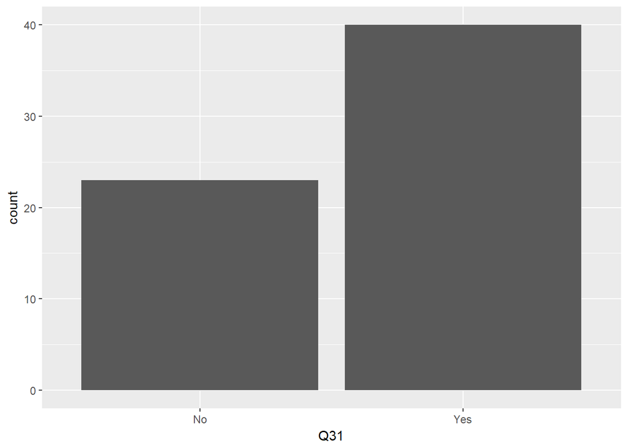

```r
survey <- survey %>%
  mutate(Q31 = sub("A", "Yes", Q31)) %>%
  mutate(Q31 = sub("B", "No", Q31))
ggplot(survey, aes(x=Q31)) + geom_bar()
```

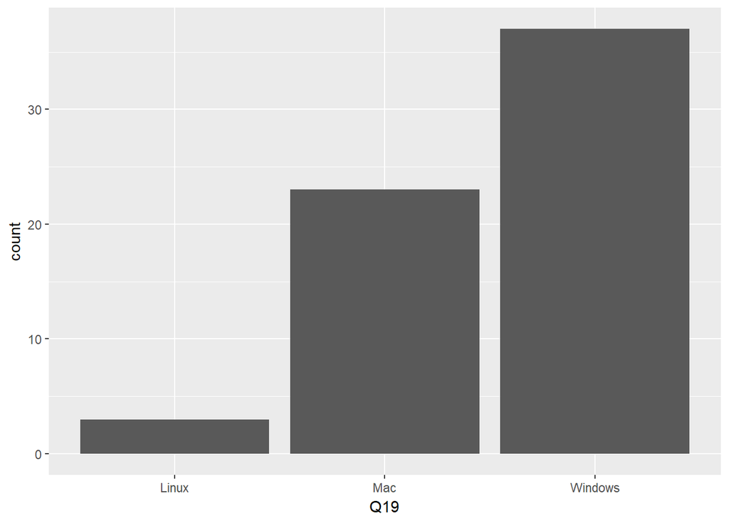

```r
survey <- survey %>%
  mutate(Q19=sub("A","Windows",Q19)) %>%
  mutate(Q19=sub("B","Mac",Q19)) %>%
  mutate(Q19=sub("C","Linux",Q19)) %>%
  mutate(Q19=sub("D", "Other", Q19))


ggplot(survey, aes(x=Q19)) + geom_bar()
```

This bar chart shows the operating systems that people use. As we can see, Windows is the most dominant one, followed by Mac and Linux. Reasons for that could be that Windows has a long history of operating systems, their system layout and settings are clear and concise, and more people are used to Windows compared to the other two. Mac is also widely used these days, while it’s sharing a market with Microsoft, We will soon see Mac on the same level as Windows given its popularity. Linux is a very complex and robust system, however the learning curve is significantly steeper when compared to Windows/Mac OSX due to the fundamental design principles. Linux was initially a server operating system not designed with user friendliness/user experience as a top priority, instead linux offers vast customisability, at the price of complex technical prerequisites from the user. As such Window’s and Mac who put the user not the function first have captured majority of the market. All across schools, universities and workplaces these 2 platforms dominate the market.

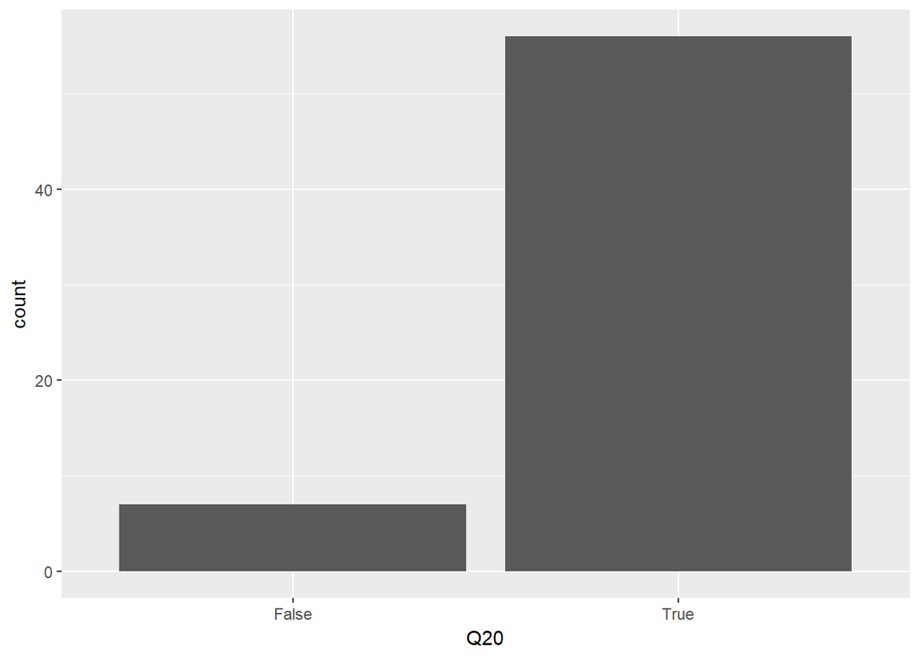

```r
ggplot(survey, aes(x=Q20)) + geom_bar()
```

This bar chart shows the amount of people supporting same-sex marriage. We can see that the vast majority of the class supports same-sex marriage. Reasons could be that our generation is more accepting than previous generations, and we believe these people should be treated equally with their relationship. Therefore the amount of people supporting it heavily outnumbers the amount of people who don’t.

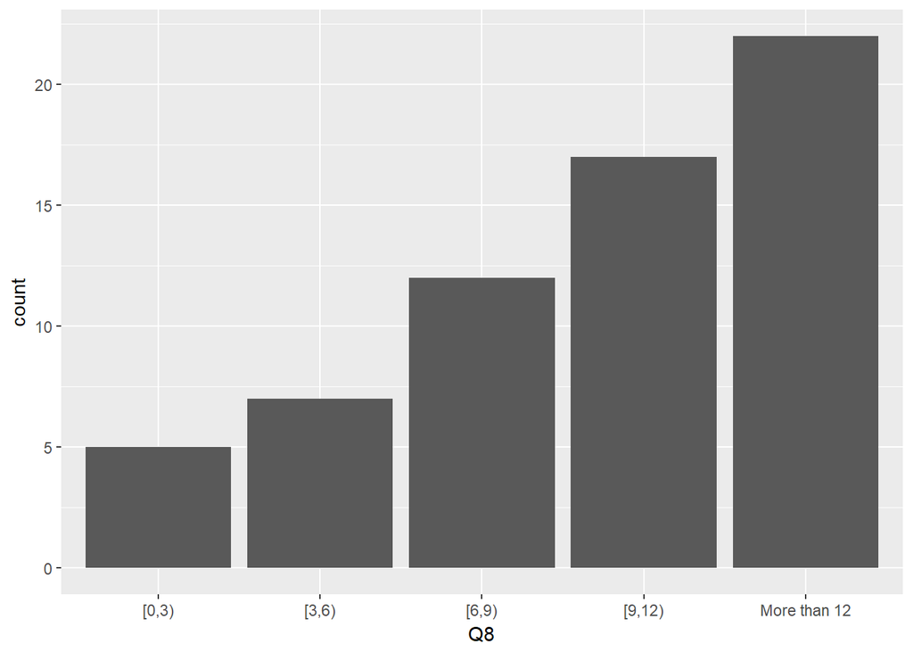

```r
survey <- survey %>%
  mutate(Q8 = sub("A", "[0,3)", Q8)) %>%
  mutate(Q8 = sub("B", "[3,6)", Q8)) %>%
  mutate(Q8 = sub("C", "[6,9)", Q8)) %>%
  mutate(Q8 = sub("D", "[9,12)", Q8)) %>%
  mutate(Q8 = sub("E", "More than 12", Q8))
ggplot(survey, aes(x=Q8)) + geom_bar()
```

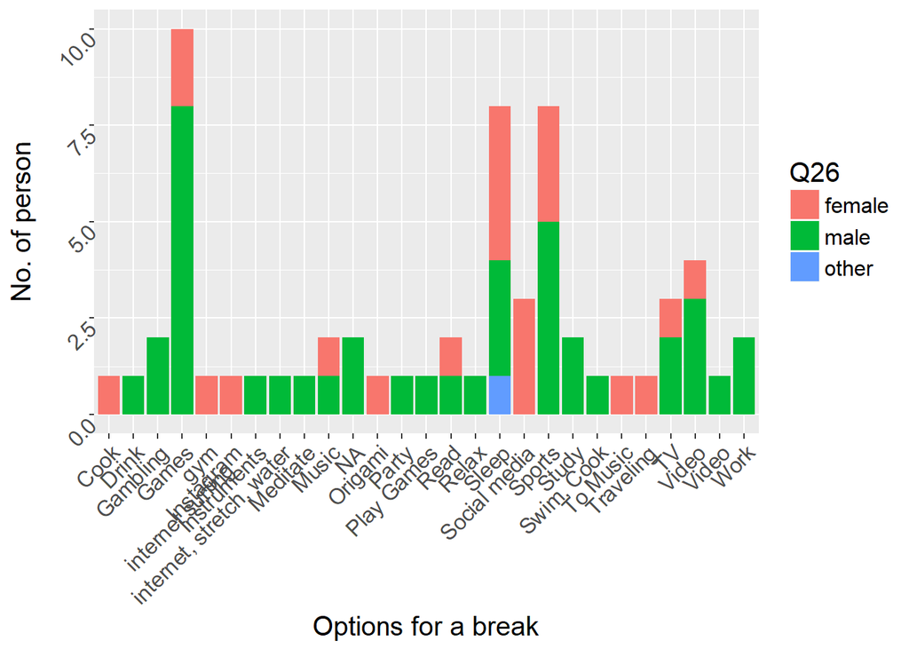

```r
survey <- survey %>%
  mutate(Q18=sub("listen to music","Music", Q18)) %>%
  mutate(Q18=sub("sport","Sports", Q18)) %>%
  mutate(Q18=sub("watch youtube","Video", Q18)) %>%
  mutate(Q18=sub("watch tv","TV", Q18)) %>%
  mutate(Q18=sub("watch vedio","Video", Q18)) %>%
  mutate(Q18=sub("gym internet surfing","Sports", Q18)) %>%
  mutate(Q18=sub("Basketball","Sports", Q18)) %>%
  mutate(Q18=sub("sleep","Sleep", Q18)) %>%
  mutate(Q18=sub("cook","Cook", Q18)) %>%
  mutate(Q18=sub("youtube","Video", Q18)) %>%
  mutate(Q18=sub("Card games","Games", Q18)) %>%
  mutate(Q18=sub("gaming","Gambling", Q18)) %>%
  mutate(Q18=sub("training my aim in different FPS games","Games", Q18)) %>%
  mutate(Q18=sub("Gym","Sport", Q18)) %>%
  mutate(Q18=sub("Climbing","Sports", Q18)) %>%
  mutate(Q18=sub("Play games","Games", Q18)) %>%
  mutate(Q18=sub("social media","Social media", Q18)) %>%
  mutate(Q18=sub("video game","Games", Q18)) %>%
  mutate(Q18=sub("computer games","Games", Q18)) %>%
  mutate(Q18=sub("play games","Games", Q18)) %>%
  mutate(Q18=sub("instagram","Social media", Q18)) %>%
  mutate(Q18=sub("Game","Games", Q18)) %>%
  mutate(Q18=sub("league of legends","Games", Q18)) %>%
  mutate(Q18=sub("Read, Play Guitar, Electronics, Sport","Read", Q18)) %>%
  mutate(Q18=sub("the office","Work", Q18)) %>%
  mutate(Q18=sub("This is us and cry","NA", Q18)) %>%
  mutate(Q18=sub("Swim, cook","Sports", Q18)) %>%
  mutate(Q18=sub("Sport","Sports", Q18)) %>%
  mutate(Q18=sub("tv","TV", Q18)) %>%
  mutate(Q18=sub("Have a trip","Traveling", Q18)) %>%
  mutate(Q18=sub("piano","Instruments", Q18)) %>%
  mutate(Q18=sub("Play video games","Games", Q18)) %>%
  mutate(Q18=sub("Study more","Study", Q18)) %>%
  mutate(Q18=sub("listen music","Music", Q18)) %>%
  mutate(Q18=sub("Watch Something/ Light Exercise","Video", Q18)) %>%
  mutate(Q18=sub("gaming","Gambling", Q18)) %>%
  mutate(Q18=sub("youtube","Video", Q18)) %>%
  mutate(Q18=sub("play my phone","Social media", Q18)) %>%
  mutate(Q18=sub("work","Work", Q18)) %>%
  mutate(Q18=sub("Hang out with friends","Social media", Q18)) %>%
  mutate(Q18=sub("Your mum","NA", Q18)) %>%
  mutate(Q18=sub("Gamess","Games", Q18)) %>%
  mutate(Q18=sub("Sportss","Sports", Q18)) %>%
  mutate(Q18=sub("Games.", "Games", Q18)) %>%
  mutate(Q18=sub("gym internet surfing", "Social media", Q18))


survey <- survey %>%
  mutate(Q26 = sub("A", "female", Q26)) %>%
  mutate(Q26 = sub("B", "male", Q26)) %>%
  mutate(Q26 = sub("C", "other", Q26))


survey <- survey %>%
  mutate(Q8 = sub("A", "[0,3)", Q8)) %>%
  mutate(Q8 = sub("B", "[3,6)", Q8)) %>%
  mutate(Q8 = sub("C", "[6,9)", Q8)) %>%
  mutate(Q8 = sub("D", "[9,12)", Q8)) %>%
  mutate(Q8 = sub("E", "More than 12", Q8))


survey <- survey %>%
  mutate(Q12 = sub("A", "Single", Q12)) %>%
  mutate(Q12 = sub("B", "Double", Q12))


ggplot(data = survey) +
  geom_bar(mapping = aes(x = Q18,fill=Q26))+theme(text=element_text(size = 15),axis.text=element_text(angle=45,vjust=1,hjust=1))+xlab("Options for a break")+ylab("No. of person")
```

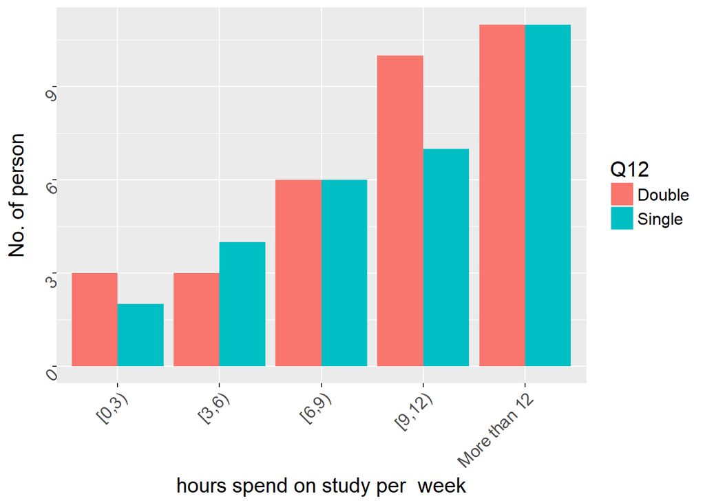

```r
ggplot(data = survey) +
  geom_bar(mapping = aes(x = Q8,fill=Q12), position = "dodge")+theme(text=element_text(size = 15),axis.text=element_text(angle=45,vjust=1,hjust=1))+xlab("hours spend on study per  week")+ylab("No. of person")
```

As we can see from the two graphs above, firstly, male’s entertainment options have more variety compared to female. With males, gaming dominates the rest, while activites such as sports and sleep follow. Comparing to males, female’s options for a break are activities like social media and sports, while only a few go to the gym or decide to cook. This can be explained by different interests between female and male, resulting in different choices of options for break. Secondly, we have a side by side bar-chart comparing study times for double and single degree students. Surprisingly, for each time duration, the amount of double and single degree students are approximately equal. This can be explained by having equally four units per semester for students regardless of their degree(s). Double degree students spend slightly more time on studying as their units may not be related to each other, whereas single degree students have the opportunity to study units that are closely related.

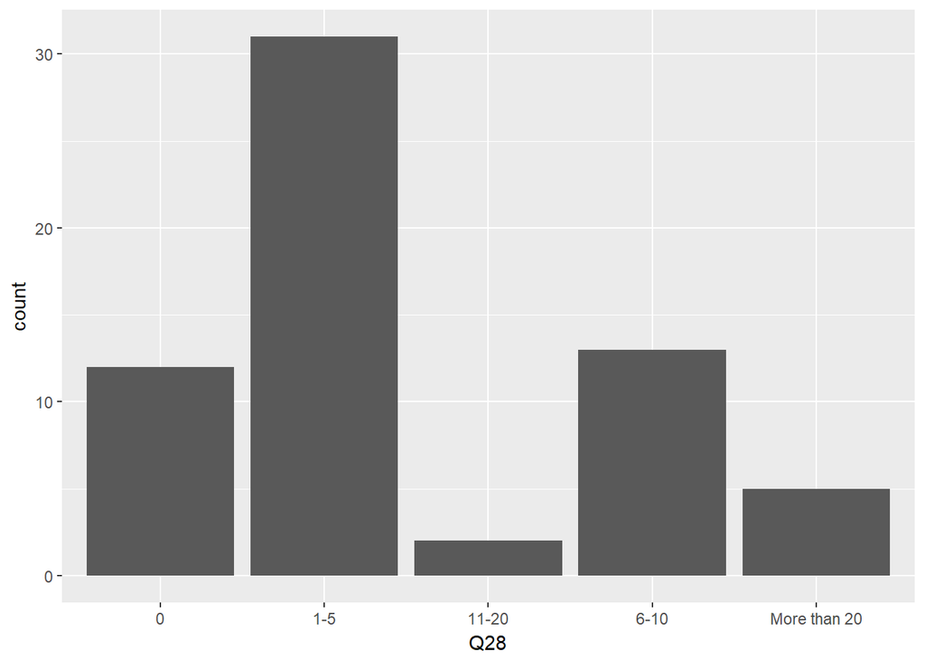

```r
survey <- survey %>%
  mutate(Q28 = sub("A", "0", Q28)) %>%
  mutate(Q28 = sub("B", "1-5", Q28)) %>%
  mutate(Q28 = sub("C", "6-10", Q28)) %>%
  mutate(Q28 = sub("D", "11-20", Q28)) %>%
  mutate(Q28 = sub("E", "More than 20", Q28))

ggplot(survey, aes(x=Q28)) + geom_bar()
```

A number of issues existed with the sample data. Mainly the limited number of observations which caused inflated effect size, whereby a few outliers pushed the mean value up. As well as low statistical power due to the small size of sample, drawing conclusions that can be accurately reproduced is very difficult with a higher chance of false data analysis.

Based on statistical publication evidence, a small sample size also does not reflect the true population “n” giving the plots lower statistical power.

```r
write_csv(survey, "Tidied survey.csv")
```